# MScFE 620 Derivative Pricing - Group Work Project

#### Question 15: Put-call parity

```python
# code from Team member A in question 11 was copied here.
# later could be deleted if Team member A has pasted the code in the same ipynb file

def merton_mc_price(S0, K, r, sigma, T, lam,
                    mu_J=-0.10, sigma_J=0.20,
                    n_paths=100_000, seed=None):
    """
    Monte Carlo pricing under the Merton jump-diffusion model.

    Returns:
        call_price, put_price
    """

    rng = np.random.default_rng(seed)

    # Standard normal shock
    Z = rng.standard_normal(n_paths)

    # Number of jumps during [0,T]
    N = rng.poisson(lam * T, n_paths)

    # Total jump contribution
    jump_size = (
        N * mu_J
        + np.sqrt(N) * sigma_J * rng.standard_normal(n_paths)
    )

    # Merton compensator
    kappa_J = np.exp(mu_J + 0.5 * sigma_J**2) - 1

    # Terminal stock price
    ST = S0 * np.exp(
        (r - 0.5 * sigma**2 - lam * kappa_J) * T
        + sigma * np.sqrt(T) * Z
        + jump_size
    )

    # Call and put payoffs
    call_payoff = np.maximum(ST - K, 0.0)
    put_payoff = np.maximum(K - ST, 0.0)

    # Discount
    discount = np.exp(-r * T)

    call_price = discount * call_payoff.mean()
    put_price = discount * put_payoff.mean()

    return call_price, put_price
```

```python
import numpy as np
import pandas as pd
import matplotlib.pyplot as plt

S0 = 100.0
r = 0.05
T = 0.25
sigma = 0.20
K_atm = 100.0

parity_theoretical = S0 - K_atm * np.exp(-r * T)

results = []

for rho in [-0.30, -0.70]:

    call_h, call_se, _ = heston_price(
        S0=S0,
        K=K_atm,
        v0=0.04,
        r=r,
        kappa=1.85,
        theta=0.04,
        xi=0.35,
        rho=rho,
        T=T,
        n_steps=100,
        n_paths=100_000,
        option_type='call',
        seed=42
    )

    put_h, put_se, _ = heston_price(
        S0=S0,
        K=K_atm,
        v0=0.04,
        r=r,
        kappa=1.85,
        theta=0.04,
        xi=0.35,
        rho=rho,
        T=T,
        n_steps=100,
        n_paths=100_000,
        option_type='put',
        seed=42
    )

    results.append({
        'Model': 'Heston',
        'param': f'rho={rho}',
        'call price': call_h,
        'put price': put_h,
        'C - P': call_h - put_h,
        'Parity RHS': parity_theoretical,
        'Parity Error': call_h - put_h - parity_theoretical
    })

for lam in [0.25, 0.75]:

    call_m, put_m = merton_mc_price(
        S0=S0,
        K=K_atm,
        r=r,
        sigma=sigma,
        T=T,
        lam=lam,
        seed=42
    )

    results.append({
        'Model': 'Merton',
        'param': f'lambda={lam}',
        'call price': call_m,
        'put price': put_m,
        'C - P': call_m - put_m,
        'Parity RHS': parity_theoretical,
        'Parity Error': call_m - put_m - parity_theoretical
    })

df_here = pd.DataFrame(results)

print('--- Question 15: Heston vs Merton Model Comparison ---')

print(
    df_here.to_string(
        formatters={
            'call price': lambda x: f'{x:.2f}',
            'put price': lambda x: f'{x:.2f}',
            'C - P': lambda x: f'{x:.4f}',
            'Parity RHS': lambda x: f'{x:.4f}',
            'Parity Error': lambda x: f'{x:.4f}'
        }
    )
)
```

[output not shown]

In all cases above [table for question 15], the simulated difference between the European call and put prices was close to parity RHS. The small residual differences are consistent with Monte Carlo sampling error / numerical discretization error. Therefore, the simulated option prices satisfy put-call parity within reasonable numerical precision.

#### Question 16: Volatility smile

It is strange that "equally-spaced strikes" while the moneyness values are "stock / strike" instead of "strike / stock".

```python
strikes_here = [85, 90.0, 95.0, 100.0, 105.0, 110.0, 115]
# strikes_reci = [S0 * S0 / k for k in strikes_here]
# strikes_here += strikes_reci
strikes_here = np.array(strikes_here)
results_here = []
for rho in [-0.30, -0.70]:
    S_heston, _ = heston_mc_paths(S0=S0, v0=0.04, r=r, kappa=1.85, theta=0.04,
                                  xi=0.35, rho=rho, T=T, n_steps=100,
                                  n_paths=100_000, seed=42)
    ST = S_heston[:,-1]
    for K in strikes_here:
        call_price = np.exp(-r * T) * np.mean(np.maximum(ST-K, 0))
        put_price  = np.exp(-r * T) * np.mean(np.maximum(K-ST, 0))
        results_here.append({
            'Model': 'Heston',
            'param': f'rho={rho}',
            'Strike': K,
            'S0/K': S0 / K,
            'K/S0': K / S0,
            'Call Price': call_price,
            'Put Price': put_price
        })
for lam in [0.25, 0.75]:
    for K in strikes_here:
        call_price, put_price = merton_mc_price(S0=S0, K=K, r=r,
                                            sigma=sigma, T=T, lam=lam, seed=42)

        results_here.append({
            'Model': 'Merton',
            'param': f'lambda={lam}',
            'Strike': K,
            'S0/K': S0 / K,
            'K/S0': K / S0,
            'Call Price': call_price,
            'Put Price': put_price
        })

tri_calls = [trinomial_tree_european(S0, k, r, sigma, T, 300, 'call'
                ) for k in strikes_here]
tri_puts = [trinomial_tree_european(S0, k, r, sigma, T, 300, 'put'
                ) for k in strikes_here]

for K, c, p in zip(strikes_here, tri_calls, tri_puts):
    results_here.append({
        'Model': 'Trinomial Constant Volatility',
        'param': 'sigma=20%',
        'Strike': K,
        'S0/K': S0 / K,
        'K/S0': K / S0,
        'Call Price': c,
        'Put Price': p
    })
```

```python
from scipy.optimize import brentq

def bs_price(S0, K, r, sigma, T, option_type='call'):
    """Black-Scholes closed-form price, used only as a sanity check."""
    d1 = (np.log(S0 / K) + (r + 0.5 * sigma ** 2) * T) / (sigma * np.sqrt(T))
    d2 = d1 - sigma * np.sqrt(T)
    if option_type == 'call':
        return S0 * norm.cdf(d1) - K * np.exp(-r * T) * norm.cdf(d2)
    else:
        return K * np.exp(-r * T) * norm.cdf(-d2) - S0 * norm.cdf(-d1)

def implied_volatility(price, S0, K, r, T, option='call'):
    def obj_(vol):
        return (bs_price(S0, K, r, vol, T, option)-price)
    try: return brentq(obj_, 1e-5, 3.0)
    except ValueError: return np.nan
```

```python
df_here = pd.DataFrame(results_here)
df_here['Implied Volatility'] = np.nan
for idx, row in df_here.iterrows():
    K = row['Strike']
    # S0 = row['S0/K'] * K
    # if row['Model'] == 'Trinomial Constant Volatility':
    #     df_here.loc[idx, 'Implied Volatility'] = 0.20
    if K < S0:
        df_here.loc[idx, 'Implied Volatility'] = implied_volatility(
            price=row['Put Price'], S0=S0, K=K, r=r, T=T, option='put')

    else:
        df_here.loc[idx, 'Implied Volatility'] = implied_volatility(
            price=row['Call Price'], S0=S0, K=K, r=r, T=T, option='call')

print('--- Question 16: Heston vs Merton vs Trinomial Model Comparison ---')

for model in ['Heston', 'Merton', 'Trinomial Constant Volatility']:
    print(model)
    df_model = df_here[df_here['Model'] == model]
    # df_here_model
    print(df_model.to_string(formatters={
        'Strike': lambda x: f'{x:.2f}',
        'S0/K': lambda x: f'{x:.2f}',
        'K/S0': lambda x: f'{x:.2f}',
        'Call Price': lambda x: f'{x:.2f}',
        'Put Price': lambda x: f'{x:.2f}'
    }))
    print()
```

```
--- Question 16: Heston vs Merton vs Trinomial Model Comparison ---
Heston
     Model     param Strike S0/K K/S0 Call Price Put Price  Implied Volatility
0   Heston  rho=-0.3  85.00 1.18 0.85      16.32      0.25              0.2230
1   Heston  rho=-0.3  90.00 1.11 0.90      11.81      0.68              0.2131
2   Heston  rho=-0.3  95.00 1.05 0.95       7.79      1.60              0.2040
3   Heston  rho=-0.3 100.00 1.00 1.00       4.56      3.31              0.1970
4   Heston  rho=-0.3 105.00 0.95 1.05       2.32      6.01              0.1919
5   Heston  rho=-0.3 110.00 0.91 1.10       1.04      9.66              0.1893
6   Heston  rho=-0.3 115.00 0.87 1.15       0.41     13.97              0.1887
7   Heston  rho=-0.7  85.00 1.18 0.85      16.41      0.34              0.2386
8   Heston  rho=-0.7  90.00 1.11 0.90      11.93      0.81              0.2253
9   Heston  rho=-0.7  95.00 1.05 0.95       7.90      1.72              0.2116
10  Heston  rho=-0.7 100.00 1.00 1.00       4.58      3.33              0.1982
11  Heston  rho=-0.7 105.00 0.95 1.05       2.19      5.88              0.1849
```

[output cut: 29 more lines]

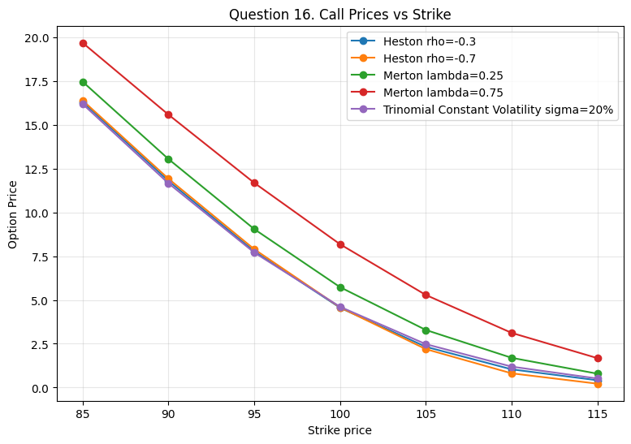

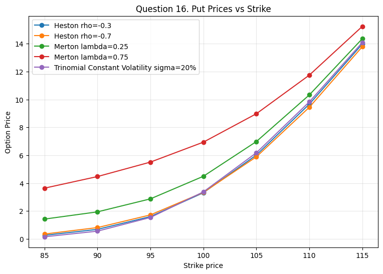

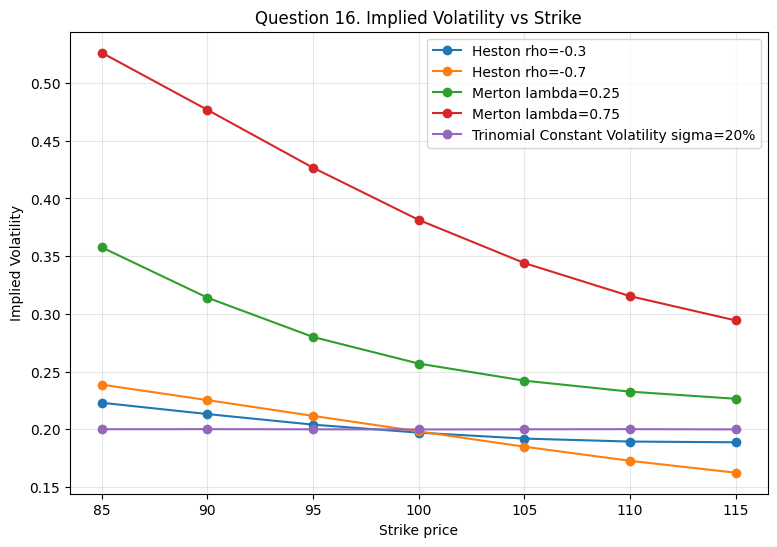

```python
def plot_comp(df_here, type_here='Call'):
    plt.figure(figsize=(9,6))
    for (model, param_), df_temp in df_here.groupby(['Model', 'param']):
        df_temp = df_temp.sort_values('Strike')
        plt.plot(df_temp['Strike'], df_temp[f'{type_here} Price'], marker='o',
                label=f'{model} {param_}')
    plt.xlabel('Strike price')
    plt.ylabel('Option Price')
    plt.title(f'Question 16. {type_here} Prices vs Strike')
    plt.legend()
    plt.grid(alpha=0.3)
    plt.show()

def plot_vol(df_here):
    plt.figure(figsize=(9,6))
    for (model, param_), df_temp in df_here.groupby(['Model', 'param']):
        plt.plot(df_temp['Strike'], df_temp['Implied Volatility'], marker='o',
                label=f'{model} {param_}')
    plt.xlabel('Strike price')
    plt.ylabel('Implied Volatility')
    plt.title(f'Question 16. Implied Volatility vs Strike')
    plt.legend()
    plt.grid(alpha=0.3)
    plt.show()

plot_comp(df_here, type_here='Call')
plot_comp(df_here,  type_here='Put')
plot_vol(df_here)
```

Across all models [Heston, Merton, constant-volatility], call prices decreased as the strike increased, while put prices increased.

- The constant-volatility trinomial model produced an approximately flat implied volatility at 0.2.
- The Heston model produced a negative volatility skew and the skew is stronger for $\rho = -0.7$ than for $\rho = -0.3$, reflecting the stronger negative relationship between returns and volatility.
- The Merton model produced higher implied volatilities, particularly at lower strikes. The model includes jump risk. The jump component introduces substantial downside-tail risk. $\lambda = 0.75$ produced higher implied volatilities than $\lambda = 0.25$ across the strike range.

### Step 3: Exotics, Path-Dependence and Hedging

#### Question 17: American call under the Heston model

```python
def heston_mc_paths_sv(S0, v0, r, kappa, theta, xi,
                       rho, T, n_steps, n_paths, seed=None):
    rng = np.random.default_rng(seed)
    dt = T / n_steps
    Z1 = rng.standard_normal((n_paths, n_steps))
    Zi = rng.standard_normal((n_paths, n_steps))
    Z2 = rho * Z1 + np.sqrt(1 - rho ** 2) * Zi
    S = np.empty((n_paths, n_steps + 1))
    v = np.empty((n_paths, n_steps + 1))
    S[:, 0] = S0
    v[:, 0] = v0
    for t in range(n_steps):
        v_pos = np.maximum(v[:, t], 0.0)
        S[:, t + 1] = S[:, t] * np.exp(
            (r - 0.5 * v_pos) * dt + np.sqrt(v_pos * dt) * Z1[:, t])
        v[:, t + 1] = v[:, t] + kappa * (
            theta - v_pos) * dt + xi * np.sqrt(v_pos * dt) * Z2[:, t]
    return S, v

def lsm_basis(S, v, K, theta):
    x = S / K
    z = np.maximum(v, 0.0) / theta
    return np.column_stack([np.ones(len(x)), x, x**2, z, z**2, x * z])

def fit_heston_call_lsm_policy(S0, K, v0, r, kappa, theta, xi, rho,
                               T, n_steps=100, n_paths=100_000, seed=42):
    S, v = heston_mc_paths_sv(S0, v0, r, kappa, theta, xi,
                              rho, T, n_steps, n_paths, seed)
    dt = T / n_steps
    cashflow = np.maximum(S[:,-1] - K, 0.0)
    exercise_time = np.full(n_paths, n_steps, dtype=int)
    betas = [None] * (n_steps + 1)
    for t in range(n_steps-1, 0, -1):
        intrinsic = np.maximum(S[:,t] - K, 0.0)
        itm = intrinsic > 0
        if np.sum(itm) < 20: continue

        Y = (cashflow[itm] * np.exp(-r * dt * (exercise_time[itm] - t)))
        X = lsm_basis(S[itm, t], v[itm, t], K, theta)
        beta, *_ = np.linalg.lstsq(X, Y, rcond=None)
        betas[t] = beta
        continuation_reg = X @ beta
        tau = T - t * dt
        continuation_lb = (S[itm, t] - K * np.exp(-r * tau))
        continuation = np.maximum(continuation_reg, continuation_lb)
        exercise_local = (intrinsic[itm] > continuation)
        itm_idx = np.where(itm)[0]
        exercise_idx = itm_idx[exercise_local]
        cashflow[exercise_idx] = (intrinsic[exercise_idx])
        exercise_time[exercise_idx] = t
    return betas

def evaluate_heston_call_lsm(S0, K, v0, r, kappa, theta, xi, rho,
                             T, betas, n_steps=100, n_paths=100_000,
                             seed=42):
    S, v = heston_mc_paths_sv(S0, v0, r, kappa, theta, xi,
                              rho, T, n_steps, n_paths, seed)
    dt = T / n_steps
    alive = np.ones(n_paths, dtype=bool)
    cashflow = np.zeros(n_paths)
    exercise_time = np.full(n_paths, n_steps, dtype=int)

    for t in range(1, n_steps):
        if betas[t] is None: continue
        intrinsic = np.maximum(S[:,t] - K, 0.0)
        candidates = alive & (intrinsic > 0)
        if np.sum(candidates) == 0: continue
        idx = np.where(candidates)[0]
        X = lsm_basis(S[idx, t], v[idx, t], K, theta)
        continuation_reg = X @ betas[t]
        tau = T - t * dt
        continuation_lb = (S[idx, t] - K * np.exp(-r * tau))
        continuation = np.maximum(continuation_reg, continuation_lb)
        exercise = (intrinsic[idx] > continuation)
        exercise_idx = idx[exercise]
        cashflow[exercise_idx] = intrinsic[exercise_idx]
        exercise_time[exercise_idx] = t
        alive[exercise_idx] = False
    cashflow[alive] = np.maximum(S[alive,-1] - K, 0.0)
    discounted_cf = cashflow * np.exp(-r * exercise_time * dt)
    price = np.mean(discounted_cf)
    stderr = (np.std(discounted_cf, ddof=1)/np.sqrt(n_paths))
    early_exercise_rate = np.mean(exercise_time < n_steps)
    return price, stderr, early_exercise_rate

def heston_american_call(S0, K, v0, r, kappa, theta, xi, rho,
                         T, n_steps, n_train=150_000, n_test=100_000, seed=42):
    betas = fit_heston_call_lsm_policy(
        S0, K, v0, r, kappa, theta, xi, rho,
        T, n_steps=n_steps, n_paths=n_train, seed=seed+1)
    return evaluate_heston_call_lsm(
        S0, K, v0, r, kappa, theta, xi, rho,
        T, betas, n_steps=n_steps, n_paths=n_test, seed=seed)
```

```python
rho_here = -0.7
eps = .1

betas = fit_heston_call_lsm_policy(
    S0=S0, K=K_atm, v0=0.04, r=r, kappa=1.85, theta=0.04, xi=0.35,
    rho=rho_here,T=T, n_steps=100, n_paths=150_000, seed=43)

c_base_am, se_base_am, ex_rate_am = evaluate_heston_call_lsm(
    S0=S0, K=K_atm, v0=0.04, r=r, kappa=1.85, theta=0.04, xi=0.35,
    rho=rho_here, T=T, betas=betas, n_steps=100, n_paths=100_000, seed=42)

c_up_am, _, _ = evaluate_heston_call_lsm(
    S0=S0+eps, K=K_atm, v0=0.04, r=r, kappa=1.85, theta=0.04, xi=0.35,
    rho=rho_here, T=T, betas=betas, n_steps=100, n_paths=100_000, seed=42)

c_dn_am, _, _ = evaluate_heston_call_lsm(
    S0=S0-eps, K=K_atm, v0=0.04, r=r, kappa=1.85, theta=0.04, xi=0.35,
    rho=rho_here, T=T, betas=betas, n_steps=100, n_paths=100_000, seed=42)

# c_base_am, se_base_am, ex_rate_am = heston_american_call(
#     S0=S0, K=K_atm, v0=0.04, r=r, kappa=1.85, theta=0.04, xi=0.35,
#     rho=rho_here,T=T, n_steps=100, seed=42)

# c_up_am, _, _  = heston_american_call(
#     S0=S0 + eps, K=K_atm, v0=0.04, r=r, kappa=1.85, theta=0.04, xi=0.35,
#     rho=rho_here,T=T, n_steps=100, seed=42)

# c_dn_am, _, _ = heston_american_call(
#     S0=S0 - eps, K=K_atm, v0=0.04, r=r, kappa=1.85, theta=0.04, xi=0.35,
#     rho=rho_here,T=T, n_steps=100, seed=42)

def get_delta_gamma(c_base, c_up, c_dn, eps=eps):
    delta_c = (c_up - c_dn) / (2 * eps)
    gamma_c = (c_up - 2 * c_base + c_dn) / (eps**2)
    return delta_c, gamma_c


c_base_eu, se_base_eu, _ = heston_price(
    S0=S0, K=K_atm, v0=0.04, r=r, kappa=1.85, theta=0.04, xi=0.35,
    rho=rho_here,T=T, n_steps=100, n_paths=100_000, seed=42, option_type='call')

c_up_eu, _, _  = heston_price(
    S0=S0 + eps, K=K_atm, v0=0.04, r=r, kappa=1.85, theta=0.04, xi=0.35,
    rho=rho_here,T=T, n_steps=100, n_paths=100_000, seed=42, option_type='call')

c_dn_eu, _, _ = heston_price(
    S0=S0 - eps, K=K_atm, v0=0.04, r=r, kappa=1.85, theta=0.04, xi=0.35,
    rho=rho_here,T=T, n_steps=100, n_paths=100_000, seed=42, option_type='call')

delta_am, gamma_am = get_delta_gamma(c_base_am, c_up_am, c_dn_am)
delta_eu, gamma_eu = get_delta_gamma(c_base_eu, c_up_eu, c_dn_eu)
print('American SE:', se_base_am)
print('European SE:', se_base_eu)
print('American early exercise rate: ', ex_rate_am)
print()
df_diff = pd.DataFrame({
    'Option': ['American Call', 'European Call'],
    'Price': [round(c_base_am, 2), round(c_base_eu, 2)],
    'Delta': [round(delta_am, 4), round(delta_eu, 4)],
    'Gamma': [round(gamma_am, 4), round(gamma_eu, 4)]
})
print('--- Question 17: American vs European Call under Heston ---')
print(df_diff.to_string(formatters={
    'Price': lambda x: f'{x:.2f}',
    'Delta': lambda x: f'{x:.4f}',
    'Gamma': lambda x: f'{x:.4f}'
}))
```

```
American SE: 0.017753542456942672
European SE: 0.017753542456942672
American early exercise rate:  0.0

--- Question 17: American vs European Call under Heston ---
          Option Price  Delta  Gamma
0  American Call  4.58 0.6221 0.0382
1  European Call  4.58 0.6221 0.0382
```

Under the Heston model with $\rho = -0.70$, the American call, delta and gamma values are identical to those of the corresponding European call.

The equality follows from the absence of dividends. Stochastic volatility changes the option value and Greeks relative to the constant-volatility case, but it does not create an early-exercise benefit for a non-divident-paying call.

#### Question 18: Up-and-in call vs plain European call

```python
K_barrier = 110.0
H = 110.0
rho_here = -0.70

S_barrier, _ = heston_mc_paths(S0=S0, v0=0.04, r=r, kappa=1.85,
                               theta=0.04, xi=0.35, rho=rho_here,
                               T=T, n_steps=100, n_paths=100_000, seed=42)
ST = S_barrier[:,-1]
barrier_hit = np.max(S_barrier, axis=1) >= H
ui_payoff = (np.maximum(ST-K_barrier, 0) * barrier_hit)
plain_payoff = np.maximum(ST-K_barrier, 0)

disc = np.exp(-r * T)
ui_price = disc * np.mean(ui_payoff)
plain_price = disc * np.mean(plain_payoff)
ui_se = (disc * np.std(ui_payoff, ddof=1) / np.sqrt(len(ui_payoff)))
plain_se = (disc * np.std(plain_payoff, ddof=1) / np.sqrt(len(plain_payoff)))

hit_rate = np.mean(barrier_hit)
df_q18 = pd.DataFrame({
    'Option': ['Up-and-In Call', 'Plain European Call'],
    'Strike': [K_barrier, K_barrier],
    'Barrier':[H, np.nan],
    'Price': [round(ui_price, 2), round(plain_price, 2)],
    'SE': [round(ui_se, 4), round(plain_se, 4)]})
print('Barrier-hit rate:', round(hit_rate, 4))

print('--- Question 18: Barrier Option Pricing ---')
# print(df_q18.to_string(index=False))
print(df_q18.to_string(formatters={
    'Strike': lambda x: f'{x:.0f}',
    'Barrier': lambda x: f'{x:.0f}',
    'Price': lambda x: f'{x:.2f}',
    'SE': lambda x: f'{x:.4f}'
}))
```

```
Barrier-hit rate: 0.2994
--- Question 18: Barrier Option Pricing ---
                Option Strike Barrier Price     SE
0       Up-and-In Call    110     110  0.81 0.0072
1  Plain European Call    110     NaN  0.81 0.0072
```

Since H = K = 110, the terminal payoff of the up-and-in call is identical to that of the plain European call.

#### Question 19: Down-and-In Barrier Put (PDI) Under Merton ($\lambda=0.75$)

```python
def merton_down_and_in_put(S0=100.0, K=90.0, H=90.0, r=0.05, sigma=0.20, T=0.25,
                           lam=0.75, mu_j=-0.5, delta=0.22, M=200000,
                           N_steps=100, seed=42):
    np.random.seed(seed)
    dt = T / N_steps
    k = np.exp(mu_j + 0.5 * delta**2) - 1.0
    drift = (r - lam * k - 0.5 * sigma**2) * dt

    log_S = np.full(M, np.log(S0))
    min_S = np.full(M, S0)

    for _ in range(N_steps):
        Z = np.random.normal(0, 1, M)
        N_jumps = np.random.poisson(lam * dt, M)
        jump_factor = np.zeros(M)
        has_jumps = N_jumps > 0
        jump_factor[has_jumps] = np.random.normal(
            N_jumps[has_jumps] * mu_j,
            np.sqrt(N_jumps[has_jumps]) * delta
        )
        log_S += drift + sigma * np.sqrt(dt) * Z + jump_factor
        S_current = np.exp(log_S)
        min_S = np.minimum(min_S, S_current)

    ST = np.exp(log_S)
    barrier_hit = min_S <= H
    payoff = np.where(barrier_hit, np.maximum(K - ST, 0), 0.0)
    return np.exp(-r * T) * np.mean(payoff)

pdi_price = merton_down_and_in_put(S0=100.0, K=90.0, H=90.0, lam=0.75)
df_q19 = pd.DataFrame({
    'Exotic Structure': ['Down-and-In Put (PDI)'],
    'Barrier (H)': [90.0],
    'Strike (K)': [90.0],
    'Price ($)': [round(pdi_price, 2)]
})
print('--- Question 19: Barrier Option Pricing ---')
print(df_q19.to_string(index=False))
```

```
--- Question 19: Barrier Option Pricing ---
     Exotic Structure  Barrier (H)  Strike (K)  Price ($)
Down-and-In Put (PDI)      90.0000     90.0000     4.4600
```

#### Question 20: Dynamic Delta Hedging by Hand

This one does not need code, as the question says.

Use:

(S_0=100) (K=100) (r=5%) (\sigma=20%) (T=0.25) 3 steps

For a CRR tree:

$$ \Delta t=\frac{0.25}{3}=0.083333 $$

$$ u=e^{\sigma\sqrt{\Delta t}}=1.059434 $$ $$ d=\frac{1}{u}=0.943900 $$ $$ R=e^{r\Delta t}=1.004175 $$ $$ p=\frac{R-d}{u-d}=0.521709 $$

The European put price is approximately:

$$ \boxed{P_0=3.7021} $$

Pick the path U-D-D

So:

$$ 100\rightarrow105.9434\rightarrow100\rightarrow94.3900 $$

The relevant option values are:

Time Stock (S) Put Value 0 100.0000 3.7021 1 105.9434 1.2727 2 100.0000 2.6720 3 94.3900 5.6100

For a put:

$$ \Delta= \frac{P_u-P_d}{S_u-S_d} $$

At (t=0):

$$ \Delta_0=-0.44244 $$

So, as the seller of the put, you short approximately 0.4424 shares.

Your initial cash account is:

$$ B_0=P_0-\Delta_0S_0 $$

$$ B_0=3.7021-(-0.44244)(100) $$ $$ \boxed{B_0=47.9461} $$ Cash-account table

For the path U-D-D:

Step Stock Price Put Value Delta Shares Held Cash Account 0 100.0000 3.7021 -0.4424 -0.4424 47.9461 1 U 105.9434 1.2727 -0.2183 -0.2183 24.4005 2 D 100.0000 2.6720 -0.4856 -0.4856 51.2291 3 D 94.3900 5.6100 0 0 5.6100

At each step:

Let the cash account earn the risk-free rate. Recalculate the Delta. Buy/sell the required number of shares. The cash account adjusts to finance the change in the stock position.

At maturity, the hedge portfolio produces exactly the put payoff for this particular binomial path.

#### Questions 21 & 22: Dynamic Hedging & Asian Put Option

```python
import numpy as np
import pandas as pd

# ============================================================
# QUESTION 21 — AMERICAN PUT AND DYNAMIC DELTA HEDGING
# ============================================================

# Parameters
S0 = 100
K = 100
r = 0.05
sigma = 0.20
T = 0.25
N_steps = 25

dt = T / N_steps
u = np.exp(sigma * np.sqrt(dt))
d = 1 / u
R = np.exp(r * dt)
p = (R - d) / (u - d)


# ------------------------------------------------------------
# 1. Build American Put Binomial Tree
# ------------------------------------------------------------

# Stock price tree
S_tree = []

for i in range(N_steps + 1):
    S_i = np.array([
        S0 * u**j * d**(i-j)
        for j in range(i + 1)
    ])
    S_tree.append(S_i)


# Option value tree
V_tree = [None] * (N_steps + 1)

# Terminal payoff
V_tree[N_steps] = np.maximum(K - S_tree[N_steps], 0)


# Backward induction
for i in range(N_steps - 1, -1, -1):

    continuation_value = np.exp(-r * dt) * (
        p * V_tree[i + 1][1:i + 2]
        + (1 - p) * V_tree[i + 1][0:i + 1]
    )

    immediate_exercise = np.maximum(
        K - S_tree[i],
        0
    )

    # American option = max(continuation, exercise)
    V_tree[i] = np.maximum(
        continuation_value,
        immediate_exercise
    )


# American Put price
am_put = V_tree[0][0]

print("--- Question 21: American Put ---")
print(f"American Put Price: ${am_put:.4f}")


# ------------------------------------------------------------
# 2. Calculate Delta at Every Node
# ------------------------------------------------------------

Delta_tree = [None] * N_steps

for i in range(N_steps):

    deltas = []

    for j in range(i + 1):

        S_down = S_tree[i + 1][j]
        S_up = S_tree[i + 1][j + 1]

        V_down = V_tree[i + 1][j]
        V_up = V_tree[i + 1][j + 1]

        delta = (V_up - V_down) / (S_up - S_down)

        deltas.append(delta)

    Delta_tree[i] = np.array(deltas)


print(f"Initial American Put Delta: {Delta_tree[0][0]:.4f}")


# ------------------------------------------------------------
# 3. Dynamic Delta Hedging Along One Path
# ------------------------------------------------------------

# Choose one path:
# U = up movement
# D = down movement
path = ["U", "D"] * (N_steps // 2) + ["U"]

# Keep exactly 25 movements
path = path[:N_steps]

j = 0

hedge_data = []

# Initial Delta
initial_delta = Delta_tree[0][0]

# For the seller of the put, hedge position = -Delta
shares = -initial_delta

# Seller receives the option premium
# and uses part of it to establish the hedge
cash = am_put - shares * S0


# Initial row
hedge_data.append({
    "Step": 0,
    "Move": "Start",
    "Stock Price": S0,
    "American Put": V_tree[0][0],
    "Option Delta": initial_delta,
    "Hedge Shares": shares,
    "Cash Account": cash
})


# Follow the selected path
for i in range(1, N_steps + 1):

    # Determine movement
    move = path[i - 1]

    if move == "U":
        j += 1

    # Stock price at this node
    S_current = S_tree[i][j]

    # American put value
    V_current = V_tree[i][j]

    # Accrue cash at risk-free rate
    cash = cash * R

    # If we are not at maturity, calculate new Delta
    if i < N_steps:

        new_delta = Delta_tree[i][j]

        # Seller's hedge position
        new_shares = -new_delta

        # Rebalance stock position
        cash -= (new_shares - shares) * S_current

        shares = new_shares

    else:

        # At maturity, the option Delta is determined
        # by whether the put finishes in-the-money
        if S_current < K:
            new_delta = -1.0
        else:
            new_delta = 0.0

        new_shares = -new_delta

        # Rebalance final stock position
        cash -= (new_shares - shares) * S_current

        shares = new_shares

    hedge_data.append({
        "Step": i,
        "Move": move,
        "Stock Price": S_current,
        "American Put": V_current,
        "Option Delta": new_delta,
        "Hedge Shares": shares,
        "Cash Account": cash
    })


# Create results table
df_q21 = pd.DataFrame(hedge_data)

print("\n--- Question 21: Dynamic Delta Hedging ---")
print(df_q21.to_string(index=False))


# ------------------------------------------------------------
# 4. Final Payoff
# ------------------------------------------------------------

final_stock = df_q21.iloc[-1]["Stock Price"]
final_payoff = max(K - final_stock, 0)

print("\n--- Final Results ---")
print(f"Final Stock Price: ${final_stock:.4f}")
print(f"American Put Payoff: ${final_payoff:.4f}")
```

```
--- Question 21: American Put ---
American Put Price: $3.5186
Initial American Put Delta: -0.4502

--- Question 21: Dynamic Delta Hedging ---
 Step  Move  Stock Price  American Put  Option Delta  Hedge Shares  Cash Account
    0 Start     100.0000        3.5186       -0.4502        0.4502      -41.5034
    1     U     102.0201        2.6334       -0.3680        0.3680      -33.1385
    2     D     100.0000        3.3970       -0.4521        0.4521      -41.5644
    3     U     102.0201        2.5079       -0.3666        0.3666      -32.8568
    4     D     100.0000        3.2684       -0.4541        0.4541      -41.6249
    5     U     102.0201        2.3754       -0.3647        0.3647      -32.5296
    6     D     100.0000        3.1320       -0.4561        0.4561      -41.6873
    7     U     102.0201        2.2349       -0.3624        0.3624      -32.1483
    8     D     100.0000        2.9867       -0.4584        0.4584      -41.7596
```

[output cut: 21 more lines]

```python
# ============================================================
# QUESTION 22 — ASIAN ARITHMETIC PUT
# ============================================================

def asian_arithmetic_put_mc(
    S0=100,
    K=100,
    r=0.05,
    sigma=0.20,
    T=0.25,
    M=200000,
    N_steps=25,
    seed=42
):

    np.random.seed(seed)

    dt = T / N_steps

    drift = (r - 0.5 * sigma**2) * dt

    # Simulate stock price paths
    S = np.zeros((M, N_steps + 1))
    S[:, 0] = S0

    for t in range(1, N_steps + 1):

        Z = np.random.normal(0, 1, M)

        S[:, t] = (
            S[:, t - 1]
            * np.exp(
                drift
                + sigma * np.sqrt(dt) * Z
            )
        )

    # Arithmetic average stock price
    S_avg = np.mean(S, axis=1)

    # Asian put payoff
    asian_payoff = np.maximum(K - S_avg, 0)

    # Discounted expected payoff
    asian_price = np.exp(-r * T) * np.mean(asian_payoff)

    return asian_price


# Calculate Asian Put price
asian_put = asian_arithmetic_put_mc()


# ------------------------------------------------------------
# Compare American Put and Asian Put
# ------------------------------------------------------------

df_q22 = pd.DataFrame({
    "Option": [
        "American Put (Q21)",
        "Asian Arithmetic Put (Q22)"
    ],
    "Price ($)": [
        round(am_put, 2),
        round(asian_put, 2)
    ]
})


print("--- Question 22: Asian vs American Put Comparison ---")
print(df_q22.to_string(index=False))
```

```
--- Question 22: Asian vs American Put Comparison ---
                    Option  Price ($)
        American Put (Q21)     3.5200
Asian Arithmetic Put (Q22)     1.9700
```